# Hunger Across Domains - Behavioural Analyses

Jennifer March (jennifer.march@uni-hamburg.de

2024-06-11

### Information

This script contains the behavioural analyses of food choice, social choice and discounting task, that is GLMMs. **Requirements** had_data.RData (in data folder from this git repository: https://github.com/JenniferMarch/Hunger_across_domains)

## 1 Preperations

### 1.1 Load Libraries

```r
#clear working environment
rm(list=ls())

#clear all plots
if(!is.null(dev.list())) dev.off()
```

```r
#load required libraries
library(readxl)
library(ggpubr)
library(rstatix)
library(readr)
library(tidyr)
library(dplyr)
library(zoo)
```

```r
library (ggplot2)
library(tibble)
#library(rstatix)
library(tidyverse)
library(Matrix)
library(ez)
library(car)
library(lme4)
library(lmerTest)
```

### 1.2 Chreate Theme for figures

```r
myTheme <- theme(
  axis.line = element_line(colour = "black"),
  panel.grid.major = element_blank(),
  panel.grid.minor = element_blank(),
  panel.border = element_blank(),
  panel.background = element_blank(),
  text=element_text(size=16, colour = "black"),
  axis.title.x = element_text(size=20, face="bold", colour = "black"),
  axis.title.y = element_text( size=20, face="bold", colour = "black"),
  axis.text = element_text(size=16),
  strip.text =  element_text( size=16),
  strip.background = element_rect(fill = "white", colour = "black"),
  legend.background = element_rect(colour = "black"),
  legend.key = element_blank(),
  legend.key.size = unit(3, "lines"))
```

### 1.3 Load Pre-processed Data

```r
load('had_data.RData')
```

## 2 Behavioural Analyses

Hypothesis 1: Hunger state affects value-based choice across domains. ### 2.1 Food Choice a) We predict that hungrier participants are more likely to choose tasty over healthy foods. This will also be reflected in shorter response times towards tasty food options in the hungry condition. #### 2.1.1 Preperation Is Random effects justified?

```r
data_combined <- data_combined %>%
  dplyr::mutate(choice2 = dplyr::recode(as.character(choice), "taste" = 1, "health" = 0))

data_combined<-data_combined %>%
  dplyr::mutate(response2=dplyr::recode(response, 'left'=1, 'right'=0))

#is random effects justified?
food_model0 <- glm(choice2~1, data=data_combined, family=binomial)
food_model1 <- glmer(choice2~(1|subject), data=data_combined, family=binomial, control = glmerControl(optimizer = "bobyqa"))
food_model2 <- glmer(choice2~(1+condition|subject), data=data_combined, family=binomial, , control = glmerControl(optimizer = "bobyqa"))

aic_glm <- AIC(logLik(food_model0))
aic_glmer1 <- AIC(logLik(food_model1))
aic_glmer2 <- AIC(logLik(food_model2))

aic_glm
```

```
## [1] 13845.4
```

```r
aic_glmer1
```

```
## [1] 13216.59
```

```r
aic_glmer2
```

```
## [1] 13017.95
```

```r
# AIC of random effects model smaller, hence better
```

add rel. dwell time difference tasty - healthy option

```r
data_combined2 <- subset(data_combined,rel_dwelldiff_chosen!='NaN')
data_combined2$dwelldiff_taste_rel <- 0
for (i in 1:nrow(data_combined2)){
  if((data_combined2$choice2[i]==1) && (data_combined2$response2[i]==1)) { # taste & left
    data_combined2$dwelldiff_taste_rel[i] = (data_combined2$foodleft_time[i]+data_combined2$nutrileft_time[i])/(data_combined2$foodright_time[i]+data_combined2$nutriright_time[i]+data_combined2$foodleft_time[i]+data_combined2$nutrileft_time[i])
  }else if ((data_combined2$choice2[i]==1) && (data_combined2$response2[i]==0)) { # taste & right
    data_combined2$dwelldiff_taste_rel[i] = (data_combined2$foodright_time[i]+data_combined2$nutriright_time[i])/(data_combined2$foodleft_time[i]+data_combined2$nutrileft_time[i]+data_combined2$foodright_time[i]+data_combined2$nutriright_time[i])
  }else if ((data_combined2$choice2[i]==0) && (data_combined2$response2[i]==1)) { # health & left
    data_combined2$dwelldiff_taste_rel[i] = (data_combined2$foodright_time[i]+data_combined2$nutriright_time[i])/(data_combined2$foodleft_time[i]+data_combined2$nutrileft_time[i]+data_combined2$foodright_time[i]+data_combined2$nutriright_time[i])
  }else if ((data_combined2$choice2[i]==0) && (data_combined2$response2[i]==0)) { # health & right
    data_combined2$dwelldiff_taste_rel[i] = (data_combined2$foodleft_time[i]+data_combined2$nutrileft_time[i])/(data_combined2$foodright_time[i]+data_combined2$nutriright_time[i]+data_combined2$foodleft_time[i]+data_combined2$nutrileft_time[i])
  }
}

datal_combined2 <- subset(data_combined2, dwelldiff_taste_rel!='NaN')
```

#### 2.1.2 Choice Models

```r
food_model3 <- glmer(choice2~condition + scale(dwelldiff_taste_rel) + (1+condition|subject), data=data_combined2, family=binomial(link="logit"), control=glmerControl(optimizer="bobyqa",optCtrl=list(maxfun=2e5)))

food_model4 <- glmer(choice2~condition + scale(dwelldiff_taste_rel) + scale(rel_dwelldiff_taste) + BMI_cent + age_cent + condition * age_cent + scale(rel_dwelldiff_taste) * BMI_cent + scale(rel_dwelldiff_taste) * age_cent  +    (1+condition|subject), data=data_combined2, family=binomial(link="logit"), control=glmerControl(optimizer="bobyqa",optCtrl=list(maxfun=2e5)))
food_model5 <- glmer(choice2~condition + scale(dwelldiff_taste_rel) + scale(rel_dwelldiff_taste) + BMI_cent + age_cent + scale(PA_change) + scale(NA_change)+ scale(hs_change) + scale(external) + scale(emotional) + scale(restricted) + scale(dwelldiff_taste_rel) * scale(restricted) + (1+condition|subject), data=data_combined2, family=binomial(link="logit"), control=glmerControl(optimizer="bobyqa",optCtrl=list(maxfun=2e5)))

summary(food_model3)
```

```
## Generalized linear mixed model fit by maximum likelihood (Laplace
##   Approximation) [glmerMod]
##  Family: binomial  ( logit )
## Formula: choice2 ~ condition + scale(dwelldiff_taste_rel) + (1 + condition |
##     subject)
##    Data: data_combined2
## Control: glmerControl(optimizer = "bobyqa", optCtrl = list(maxfun = 2e+05))
##
##      AIC      BIC   logLik deviance df.resid
##  11200.2  11243.8  -5594.1  11188.2    10452
##
## Scaled residuals:
##     Min      1Q  Median      3Q     Max
## -6.7367 -0.7259  0.3610  0.6205  7.4696
##
## Random effects:
##  Groups  Name           Variance Std.Dev. Corr
##  subject (Intercept)    0.6345   0.7966
##          conditionsated 0.5697   0.7548   -0.59
## Number of obs: 10458, groups:  subject, 70
##
## Fixed effects:
##                            Estimate Std. Error z value Pr(>|z|)
## (Intercept)                 0.83207    0.10192   8.164 3.24e-16 ***
## conditionsated             -0.21117    0.10300  -2.050   0.0403 *
## scale(dwelldiff_taste_rel)  0.99848    0.02746  36.363  < 2e-16 ***
## ---
## Signif. codes:  0 '***' 0.001 '**' 0.01 '*' 0.05 '.' 0.1 ' ' 1
##
## Correlation of Fixed Effects:
##             (Intr) cndtns
## conditinstd -0.608
## scl(dwll__)  0.057 -0.003
```

```r
summary(food_model4)
```

```
## Generalized linear mixed model fit by maximum likelihood (Laplace
##   Approximation) [glmerMod]
##  Family: binomial  ( logit )
## Formula:
## choice2 ~ condition + scale(dwelldiff_taste_rel) + scale(rel_dwelldiff_taste) +
##     BMI_cent + age_cent + condition * age_cent + scale(rel_dwelldiff_taste) *
##     BMI_cent + scale(rel_dwelldiff_taste) * age_cent + (1 + condition |
##     subject)
##    Data: data_combined2
## Control: glmerControl(optimizer = "bobyqa", optCtrl = list(maxfun = 2e+05))
##
##      AIC      BIC   logLik deviance df.resid
##  11185.7  11272.7  -5580.8  11161.7    10446
##
## Scaled residuals:
##     Min      1Q  Median      3Q     Max
## -6.9878 -0.7220  0.3595  0.6213  7.2913
##
## Random effects:
##  Groups  Name           Variance Std.Dev. Corr
##  subject (Intercept)    0.5854   0.7651
##          conditionsated 0.4656   0.6824   -0.58
## Number of obs: 10458, groups:  subject, 70
##
## Fixed effects:
##                                      Estimate Std. Error z value Pr(>|z|)
## (Intercept)                          0.816819   0.098447   8.297  < 2e-16 ***
## conditionsated                      -0.185736   0.095596  -1.943  0.05202 .
## scale(dwelldiff_taste_rel)           0.998743   0.027490  36.331  < 2e-16 ***
## scale(rel_dwelldiff_taste)           0.092513   0.028320   3.267  0.00109 **
## BMI_cent                             0.014579   0.018840   0.774  0.43902
## age_cent                            -0.022522   0.012524  -1.798  0.07214 .
## conditionsated:age_cent              0.021861   0.012146   1.800  0.07188 .
## scale(rel_dwelldiff_taste):BMI_cent -0.016803   0.008783  -1.913  0.05574 .
## scale(rel_dwelldiff_taste):age_cent -0.010825   0.004093  -2.645  0.00817 **
## ---
## Signif. codes:  0 '***' 0.001 '**' 0.01 '*' 0.05 '.' 0.1 ' ' 1
##
## Correlation of Fixed Effects:
##             (Intr) cndtns scl(d__) scl(r__) BMI_cn ag_cnt cndt:_ s(__):B
## conditinstd -0.596
## scl(dwll__)  0.058 -0.002
## scl(rl_dw_) -0.028  0.048  0.012
## BMI_cent     0.000 -0.003  0.008    0.011
## age_cent     0.011 -0.009  0.000   -0.003   -0.148
## cndtnstd:g_ -0.010  0.022  0.002   -0.019   -0.002 -0.589
## sc(__):BMI_  0.011 -0.004 -0.029   -0.015   -0.078 -0.010 -0.004
## scl(rl__):_ -0.003 -0.018 -0.014    0.046   -0.017 -0.057  0.040 -0.002
```

```r
summary(food_model5)
```

```
## Generalized linear mixed model fit by maximum likelihood (Laplace
##   Approximation) [glmerMod]
##  Family: binomial  ( logit )
## Formula:
## choice2 ~ condition + scale(dwelldiff_taste_rel) + scale(rel_dwelldiff_taste) +
##     BMI_cent + age_cent + scale(PA_change) + scale(NA_change) +
##     scale(hs_change) + scale(external) + scale(emotional) + scale(restricted) +
##     scale(dwelldiff_taste_rel) * scale(restricted) + (1 + condition |
##     subject)
##    Data: data_combined2
## Control: glmerControl(optimizer = "bobyqa", optCtrl = list(maxfun = 2e+05))
##
##      AIC      BIC   logLik deviance df.resid
##   8594.4   8706.2  -4281.2   8562.4     7978
##
## Scaled residuals:
##     Min      1Q  Median      3Q     Max
## -6.2440 -0.7191  0.3612  0.6280  5.4178
##
## Random effects:
##  Groups  Name           Variance Std.Dev. Corr
##  subject (Intercept)    0.5767   0.7594
##          conditionsated 0.5218   0.7223   -0.66
## Number of obs: 7994, groups:  subject, 53
##
## Fixed effects:
##                                               Estimate Std. Error z value
## (Intercept)                                   0.786832   0.136357   5.770
## conditionsated                               -0.168383   0.197374  -0.853
## scale(dwelldiff_taste_rel)                    0.996439   0.031207  31.930
## scale(rel_dwelldiff_taste)                    0.101194   0.031156   3.248
## BMI_cent                                      0.009327   0.019835   0.470
## age_cent                                     -0.007168   0.012139  -0.591
## scale(PA_change)                             -0.078626   0.066877  -1.176
## scale(NA_change)                             -0.055184   0.083945  -0.657
## scale(hs_change)                              0.044396   0.113360   0.392
## scale(external)                               0.051710   0.102079   0.507
## scale(emotional)                             -0.055532   0.106148  -0.523
## scale(restricted)                             0.007561   0.093508   0.081
## scale(dwelldiff_taste_rel):scale(restricted)  0.173629   0.030821   5.634
##                                              Pr(>|z|)
## (Intercept)                                  7.91e-09 ***
## conditionsated                                0.39359
## scale(dwelldiff_taste_rel)                    < 2e-16 ***
## scale(rel_dwelldiff_taste)                    0.00116 **
## BMI_cent                                      0.63817
## age_cent                                      0.55483
## scale(PA_change)                              0.23972
## scale(NA_change)                              0.51094
## scale(hs_change)                              0.69533
## scale(external)                               0.61246
## scale(emotional)                              0.60087
## scale(restricted)                             0.93556
## scale(dwelldiff_taste_rel):scale(restricted) 1.77e-08 ***
## ---
## Signif. codes:  0 '***' 0.001 '**' 0.01 '*' 0.05 '.' 0.1 ' ' 1
```

```
##
## Correlation matrix not shown by default, as p = 13 > 12.
## Use print(x, correlation=TRUE)  or
##     vcov(x)        if you need it
```

```r
anova(food_model3, food_model4)
```

```
## Data: data_combined2
## Models:
## food_model3: choice2 ~ condition + scale(dwelldiff_taste_rel) + (1 + condition | subject)
## food_model4: choice2 ~ condition + scale(dwelldiff_taste_rel) + scale(rel_dwelldiff_taste) + BMI_cent + age_cent + condition * age_cent + scale(rel_dwelldiff_taste) * BMI_cent + scale(rel_dwelldiff_taste) * age_cent + (1 + condition | subject)
##             npar   AIC   BIC  logLik deviance  Chisq Df Pr(>Chisq)
## food_model3    6 11200 11244 -5594.1    11188
## food_model4   12 11186 11273 -5580.8    11162 26.549  6  0.0001758 ***
## ---
## Signif. codes:  0 '***' 0.001 '**' 0.01 '*' 0.05 '.' 0.1 ' ' 1
```

#### 2.1.3 RT

```r
food_RTmodel0 <- glm(RT/1000~1, data=data_combined2,family=Gamma(link="identity"))
food_RTmodel1 <- glmer(RT/1000~(1|subject), data=data_combined2,family=Gamma(link="identity"))
food_RTmodel2 <- glmer(RT/1000~(1+condition|subject), data=data_combined2,family=Gamma(link="identity"))
aic_glm <- AIC(logLik(food_RTmodel0))
aic_glmer <- AIC(logLik(food_RTmodel1))
aic_glmer2 <- AIC(logLik(food_RTmodel2))
aic_glm
```

```
## [1] 28544.95
```

```r
aic_glmer
```

```
## [1] 24556.97
```

```r
aic_glmer2
```

```
## [1] 23438.93
```

```r
food_modelRT3 <- glmer(RT/1000~condition + choice2 * scale(dwelldiff_taste_rel) + (1+condition|subject), data=data_combined2, family=Gamma(link="identity"), control=glmerControl(optimizer="bobyqa",optCtrl=list(maxfun=2e5)))
food_modelRT4 <- glmer(RT/1000~condition + choice2 + scale(dwelldiff_taste_rel) + scale(rel_dwelldiff_taste) + BMI_cent + age_cent + choice2 * scale(dwelldiff_taste_rel)  + condition * age_cent + scale(rel_dwelldiff_taste) * BMI_cent + scale(rel_dwelldiff_taste) * age_cent  +    (1+condition|subject), data=data_combined2, family=Gamma(link="identity"), control=glmerControl(optimizer="bobyqa",optCtrl=list(maxfun=2e5)))
summary(food_modelRT3)
```

```
## Generalized linear mixed model fit by maximum likelihood (Laplace
##   Approximation) [glmerMod]
##  Family: Gamma  ( identity )
## Formula: RT/1000 ~ condition + choice2 * scale(dwelldiff_taste_rel) +
##     (1 + condition | subject)
##    Data: data_combined2
## Control: glmerControl(optimizer = "bobyqa", optCtrl = list(maxfun = 2e+05))
##
##      AIC      BIC   logLik deviance df.resid
##  23303.8  23369.1 -11642.9  23285.8    10449
##
## Scaled residuals:
##     Min      1Q  Median      3Q     Max
## -2.0748 -0.6017 -0.2435  0.3204 10.6431
##
## Random effects:
##  Groups   Name           Variance Std.Dev. Corr
##  subject  (Intercept)    0.1241   0.3523
##           conditionsated 0.1598   0.3997   -0.51
##  Residual                0.1220   0.3493
## Number of obs: 10458, groups:  subject, 70
##
## Fixed effects:
##                                    Estimate Std. Error t value Pr(>|z|)
## (Intercept)                         2.74796    0.09593  28.644  < 2e-16 ***
## conditionsated                      0.03230    0.09879   0.327    0.744
## choice2                            -0.15018    0.01805  -8.320  < 2e-16 ***
## scale(dwelldiff_taste_rel)          0.06508    0.01391   4.678 2.89e-06 ***
## choice2:scale(dwelldiff_taste_rel) -0.13084    0.01727  -7.574 3.61e-14 ***
## ---
## Signif. codes:  0 '***' 0.001 '**' 0.01 '*' 0.05 '.' 0.1 ' ' 1
##
## Correlation of Fixed Effects:
##             (Intr) cndtns choic2 sc(__)
## conditinstd -0.444
## choice2     -0.133  0.003
## scl(dwll__)  0.088  0.000 -0.483
## chc2:sc(__) -0.071  0.003  0.283 -0.828
```

```r
summary(food_modelRT4)
```

```
## Generalized linear mixed model fit by maximum likelihood (Laplace
##   Approximation) [glmerMod]
##  Family: Gamma  ( identity )
## Formula: RT/1000 ~ condition + choice2 + scale(dwelldiff_taste_rel) +
##     scale(rel_dwelldiff_taste) + BMI_cent + age_cent + choice2 *
##     scale(dwelldiff_taste_rel) + condition * age_cent + scale(rel_dwelldiff_taste) *
##     BMI_cent + scale(rel_dwelldiff_taste) * age_cent + (1 + condition |
##     subject)
##    Data: data_combined2
## Control: glmerControl(optimizer = "bobyqa", optCtrl = list(maxfun = 2e+05))
##
##      AIC      BIC   logLik deviance df.resid
##  23028.3  23137.1 -11499.1  22998.3    10443
##
## Scaled residuals:
##     Min      1Q  Median      3Q     Max
## -2.1033 -0.6030 -0.2355  0.3241 10.9824
##
## Random effects:
##  Groups   Name           Variance Std.Dev. Corr
##  subject  (Intercept)    0.1170   0.3420
##           conditionsated 0.1519   0.3898   -0.52
##  Residual                0.1188   0.3447
## Number of obs: 10458, groups:  subject, 70
##
## Fixed effects:
##                                       Estimate Std. Error t value Pr(>|z|)
## (Intercept)                          2.7595625  0.0935667  29.493  < 2e-16 ***
## conditionsated                       0.0038772  0.0967368   0.040    0.968
## choice2                             -0.1448016  0.0177227  -8.170 3.07e-16 ***
## scale(dwelldiff_taste_rel)           0.0660361  0.0135742   4.865 1.15e-06 ***
## scale(rel_dwelldiff_taste)          -0.1674453  0.0111180 -15.061  < 2e-16 ***
## BMI_cent                             0.0123765  0.0181346   0.682    0.495
## age_cent                             0.0005566  0.0113534   0.049    0.961
## choice2:scale(dwelldiff_taste_rel)  -0.1322613  0.0168970  -7.827 4.98e-15 ***
## conditionsated:age_cent              0.0122465  0.0113805   1.076    0.282
## scale(rel_dwelldiff_taste):BMI_cent -0.0036913  0.0035353  -1.044    0.296
## scale(rel_dwelldiff_taste):age_cent -0.0074222  0.0016729  -4.437 9.14e-06 ***
## ---
## Signif. codes:  0 '***' 0.001 '**' 0.01 '*' 0.05 '.' 0.1 ' ' 1
```

[output cut: 9 more lines]

```
## chc2:sc(__) -0.071  0.003  0.279 -0.826   -0.001    0.003  0.000
## cndtnstd:g_  0.019 -0.062 -0.005  0.000   -0.006    0.006 -0.464  0.001
## sc(__):BMI_  0.002  0.000  0.004  0.006    0.066   -0.048  0.000 -0.006 -0.002
## scl(rl__):_ -0.007 -0.006  0.015 -0.006    0.064   -0.001 -0.037  0.002  0.010
##             s(__):B
## conditinstd
## choice2
## scl(dwll__)
## scl(rl_dw_)
## BMI_cent
## age_cent
## chc2:sc(__)
## cndtnstd:g_
## sc(__):BMI_
## scl(rl__):_ -0.033
```

```r
anova(food_modelRT3, food_modelRT4)
```

```
## Data: data_combined2
## Models:
## food_modelRT3: RT/1000 ~ condition + choice2 * scale(dwelldiff_taste_rel) + (1 + condition | subject)
## food_modelRT4: RT/1000 ~ condition + choice2 + scale(dwelldiff_taste_rel) + scale(rel_dwelldiff_taste) + BMI_cent + age_cent + choice2 * scale(dwelldiff_taste_rel) + condition * age_cent + scale(rel_dwelldiff_taste) * BMI_cent + scale(rel_dwelldiff_taste) * age_cent + (1 + condition | subject)
##               npar   AIC   BIC logLik deviance  Chisq Df Pr(>Chisq)
## food_modelRT3    9 23304 23369 -11643    23286
## food_modelRT4   15 23028 23137 -11499    22998 287.55  6  < 2.2e-16 ***
## ---
## Signif. codes:  0 '***' 0.001 '**' 0.01 '*' 0.05 '.' 0.1 ' ' 1
```

#### 2.1.4 Quantify effect of hunger

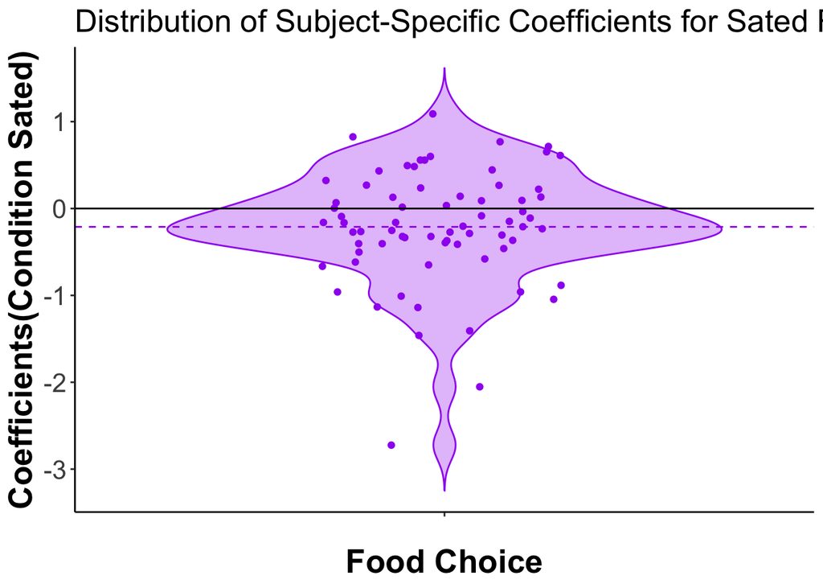

```r
# Extract the fixed effects
fixed_effects <- fixef(food_model3)

# Extract the random effects for each subject
random_effects <- ranef(food_model3)$subject

# Extract the fixed effect for `condition`
fixed_condition <- fixed_effects["conditionsated"]

# Extract the random slope for `condition`
random_condition <- ranef(food_model3)$subject[,"conditionsated"]

# Subject-specific coefficients for `condition`
subject_specific_condition <- fixed_condition + random_condition

subject_specific_df <- data.frame(
  subject = rownames(random_effects),
  condition_effect = subject_specific_condition
)

library(ggplot2)
food_plot<-ggplot(subject_specific_df, aes(x = "", y = condition_effect)) +
  geom_violin(trim = FALSE, color="purple", fill="purple", alpha=0.3) +
  geom_jitter(width = 0.2, color="purple") +
  geom_hline(yintercept = fixed_condition, color = "purple", linetype = "dashed") +
  geom_hline(yintercept = 0, color = "black", linetype = "solid") +
  myTheme +
  labs(title = "Distribution of Subject-Specific Coefficients for Sated Relative to Hungry Condition",
       x = "Food Choice",
       y = "Coefficients(Condition Sated)") +
  myTheme
food_plot
```

### 2.2 Social

We predict a substantial spillover effect of hunger state on social decisions, that is, hungry participants are more likely to choose in line with their idiosyncratic tendencies (i.e., egoistic individuals are more likely to choose egoistic options in a hungry compared to a satiated state and altruistic individuals are more likely to choose an altruistic option in a hungry compared to a satiated state). This will also be reflected in shorter response times towards participants idiosyncratic preference in the hungry condition. #### 2.2.1 Preperation Is Random effects justified?

```r
data_social_combined <- data_social_combined %>%
  mutate(choice = ifelse(
    (self_left > self_right & response == 'left') |
    (self_left < self_right & response == 'right'),
    "selfish",
    "prosocial"
  ))

data_social_combined <- data_social_combined %>%
  mutate(choice2 = case_when(
    choice == "selfish" ~ 1,
    choice == "prosocial" ~ 0,
    TRUE ~ NA_real_  # Handle other cases, if any
  ))

data_social_combined <- data_social_combined %>%
  mutate(response2 = case_when(
    response == "left" ~ 1,
    response == "right" ~ 0,
    TRUE ~ NA_real_  # Handle other cases, if any
  ))

#is random effects justified?
social_model0 <- glm(choice2~1, data=data_social_combined, family=binomial)
social_model1 <- glmer(choice2~(1|subject), data=data_social_combined, family=binomial, control = glmerControl(optimizer = "bobyqa"))
social_model2 <- glmer(choice2~(1+condition|subject), data=data_social_combined, family=binomial, , control = glmerControl(optimizer = "bobyqa"))

AIC(logLik(social_model0))
```

```
## [1] 35975.64
```

```r
AIC(logLik(social_model1))
```

```
## [1] 27454.43
```

```r
AIC(logLik(social_model2))
```

```
## [1] 25349.16
```

```r
# AIC of random effects model smaller, hence better
```

add rel. dwell time difference selfish - prosocial option

```r
data_social_combined$dwelldiff_self_rel <- 0
for (i in 1:nrow(data_social_combined)){
  if((data_social_combined$choice2[i]==1) && (data_social_combined$response2[i]==1)) { # self & left
    data_social_combined$dwelldiff_self_rel[i] = (data_social_combined$selfleft_time[i]+data_social_combined$ngoleft_time[i])/(data_social_combined$selfright_time[i]+data_social_combined$ngoright_time[i]+data_social_combined$selfleft_time[i]+data_social_combined$ngoleft_time[i])
  }else if ((data_social_combined$choice2[i]==1) && (data_social_combined$response2[i]==0)) { # self & right
    data_social_combined$dwelldiff_self_rel[i] = (data_social_combined$selfright_time[i]+data_social_combined$ngoright_time[i])/(data_social_combined$selfleft_time[i]+data_social_combined$ngoleft_time[i]+data_social_combined$selfright_time[i]+data_social_combined$ngoright_time[i])
  }else if ((data_social_combined$choice2[i]==0) && (data_social_combined$response2[i]==1)) { # ngo & left
    data_social_combined$dwelldiff_self_rel[i] = (data_social_combined$selfright_time[i]+data_social_combined$ngoright_time[i])/(data_social_combined$selfleft_time[i]+data_social_combined$ngoleft_time[i]+data_social_combined$selfright_time[i]+data_social_combined$ngoright_time[i])
  }else if ((data_social_combined$choice2[i]==0) && (data_social_combined$response2[i]==0)) { # ngo & right
    data_social_combined$dwelldiff_self_rel[i] = (data_social_combined$selfleft_time[i]+data_social_combined$ngoleft_time[i])/(data_social_combined$selfright_time[i]+data_social_combined$ngoright_time[i]+data_social_combined$selfleft_time[i]+data_social_combined$ngoleft_time[i])
  }
}

data_social_combined <- subset(data_social_combined,dwelldiff_self_rel!='NaN')
```

#### 2.2.2 Choice Model

```r
social_model3 <- glmer(choice2~condition + scale(dwelldiff_self_rel) + (1+condition|subject), data=data_social_combined, family=binomial(link="logit"), control=glmerControl(optimizer="bobyqa",optCtrl=list(maxfun=2e5)))

social_model4 <- glmer(choice2~condition + scale(dwelldiff_self_rel) + scale(rel_dwelldiff_self) + BMI_cent + age_cent + condition * age_cent + scale(rel_dwelldiff_self) * BMI_cent + scale(rel_dwelldiff_self) * age_cent  +    (1+condition|subject), data=data_social_combined, family=binomial(link="logit"), control=glmerControl(optimizer="bobyqa",optCtrl=list(maxfun=2e5)))
social_model5 <- glmer(choice2~condition + scale(dwelldiff_self_rel) + scale(rel_dwelldiff_self) + BMI_cent + age_cent + scale(PA_change) + scale(NA_change)+ scale(hs_change) + scale(external) + scale(emotional) + scale(restricted) + scale(dwelldiff_self_rel) * scale(restricted) + (1+condition|subject), data=data_social_combined, family=binomial(link="logit"), control=glmerControl(optimizer="bobyqa",optCtrl=list(maxfun=2e5)))

summary(social_model3)
```

```
## Generalized linear mixed model fit by maximum likelihood (Laplace
##   Approximation) [glmerMod]
##  Family: binomial  ( logit )
## Formula: choice2 ~ condition + scale(dwelldiff_self_rel) + (1 + condition |
##     subject)
##    Data: data_social_combined
## Control: glmerControl(optimizer = "bobyqa", optCtrl = list(maxfun = 2e+05))
##
##      AIC      BIC   logLik deviance df.resid
##  19099.0  19147.6  -9543.5  19087.0    23965
##
## Scaled residuals:
##      Min       1Q   Median       3Q      Max
## -18.6100  -0.4529  -0.1078   0.4247  21.8075
##
## Random effects:
##  Groups  Name           Variance Std.Dev. Corr
##  subject (Intercept)    3.084    1.756
##          conditionsated 1.913    1.383    -0.39
## Number of obs: 23971, groups:  subject, 70
##
## Fixed effects:
##                           Estimate Std. Error z value Pr(>|z|)
## (Intercept)               -0.53854    0.21305  -2.528   0.0115 *
## conditionsated            -0.18657    0.17326  -1.077   0.2816
## scale(dwelldiff_self_rel)  1.44414    0.02543  56.787   <2e-16 ***
## ---
## Signif. codes:  0 '***' 0.001 '**' 0.01 '*' 0.05 '.' 0.1 ' ' 1
##
## Correlation of Fixed Effects:
##             (Intr) cndtns
## conditinstd -0.402
## scl(dwll__) -0.019  0.002
```

```r
summary(social_model4)
```

```
## Generalized linear mixed model fit by maximum likelihood (Laplace
##   Approximation) [glmerMod]
##  Family: binomial  ( logit )
## Formula:
## choice2 ~ condition + scale(dwelldiff_self_rel) + scale(rel_dwelldiff_self) +
##     BMI_cent + age_cent + condition * age_cent + scale(rel_dwelldiff_self) *
##     BMI_cent + scale(rel_dwelldiff_self) * age_cent + (1 + condition |
##     subject)
##    Data: data_social_combined
## Control: glmerControl(optimizer = "bobyqa", optCtrl = list(maxfun = 2e+05))
##
##      AIC      BIC   logLik deviance df.resid
##  19044.5  19141.5  -9510.3  19020.5    23959
##
## Scaled residuals:
##      Min       1Q   Median       3Q      Max
## -19.5445  -0.4502  -0.1080   0.4220  22.1613
##
## Random effects:
##  Groups  Name           Variance Std.Dev. Corr
##  subject (Intercept)    3.360    1.833
##          conditionsated 2.193    1.481    -0.38
## Number of obs: 23971, groups:  subject, 70
##
## Fixed effects:
##                                     Estimate Std. Error z value Pr(>|z|)
## (Intercept)                        -0.553465   0.222004  -2.493   0.0127 *
## conditionsated                     -0.188906   0.184807  -1.022   0.3067
## scale(dwelldiff_self_rel)           1.453331   0.025516  56.958  < 2e-16 ***
## scale(rel_dwelldiff_self)          -0.229790   0.029698  -7.737 1.01e-14 ***
## BMI_cent                            0.017647   0.048208   0.366   0.7143
## age_cent                           -0.071328   0.028989  -2.461   0.0139 *
## conditionsated:age_cent             0.018984   0.024495   0.775   0.4383
## scale(rel_dwelldiff_self):BMI_cent  0.007672   0.005580   1.375   0.1692
## scale(rel_dwelldiff_self):age_cent -0.009512   0.004782  -1.989   0.0467 *
## ---
## Signif. codes:  0 '***' 0.001 '**' 0.01 '*' 0.05 '.' 0.1 ' ' 1
##
## Correlation of Fixed Effects:
##             (Intr) cndtns scl(d__) scl(r__) BMI_cn ag_cnt cndt:_ s(__):B
## conditinstd -0.389
## scl(dwll__) -0.018  0.001
## scl(rl_dw_)  0.002  0.007 -0.084
## BMI_cent    -0.004 -0.008 -0.003   -0.015
## age_cent     0.021 -0.019 -0.006    0.033   -0.164
## cndtnstd:g_ -0.020  0.041  0.011   -0.009   -0.014 -0.407
## sc(__):BMI_ -0.017  0.008  0.033   -0.067   -0.028  0.004 -0.002
## scl(rl__):_  0.023 -0.007 -0.006    0.192    0.002  0.049  0.008 -0.124
```

```r
summary(social_model5)
```

```
## Generalized linear mixed model fit by maximum likelihood (Laplace
##   Approximation) [glmerMod]
##  Family: binomial  ( logit )
## Formula:
## choice2 ~ condition + scale(dwelldiff_self_rel) + scale(rel_dwelldiff_self) +
##     BMI_cent + age_cent + scale(PA_change) + scale(NA_change) +
##     scale(hs_change) + scale(external) + scale(emotional) + scale(restricted) +
##     scale(dwelldiff_self_rel) * scale(restricted) + (1 + condition |
##     subject)
##    Data: data_social_combined
## Control: glmerControl(optimizer = "bobyqa", optCtrl = list(maxfun = 2e+05))
##
##      AIC      BIC   logLik deviance df.resid
##  14146.6  14271.1  -7057.3  14114.6    17644
##
## Scaled residuals:
##      Min       1Q   Median       3Q      Max
## -17.7743  -0.4554  -0.0848   0.4266  22.8959
##
## Random effects:
##  Groups  Name           Variance Std.Dev. Corr
##  subject (Intercept)    2.438    1.561
##          conditionsated 2.417    1.555    -0.23
## Number of obs: 17660, groups:  subject, 53
##
## Fixed effects:
##                                             Estimate Std. Error z value
## (Intercept)                                 -0.82106    0.27085  -3.031
## conditionsated                               0.62267    0.40244   1.547
## scale(dwelldiff_self_rel)                    1.44664    0.02912  49.679
## scale(rel_dwelldiff_self)                   -0.24328    0.03379  -7.200
## BMI_cent                                     0.04231    0.04970   0.851
## age_cent                                    -0.04337    0.02967  -1.462
## scale(PA_change)                             0.08498    0.13890   0.612
## scale(NA_change)                             0.06692    0.16724   0.400
## scale(hs_change)                             0.51444    0.24112   2.134
## scale(external)                             -0.07867    0.26286  -0.299
## scale(emotional)                            -0.44670    0.27811  -1.606
## scale(restricted)                           -0.10456    0.24017  -0.435
## scale(dwelldiff_self_rel):scale(restricted)  0.02450    0.02848   0.860
##                                             Pr(>|z|)
## (Intercept)                                  0.00243 **
## conditionsated                               0.12181
## scale(dwelldiff_self_rel)                    < 2e-16 ***
## scale(rel_dwelldiff_self)                   6.01e-13 ***
## BMI_cent                                     0.39459
## age_cent                                     0.14372
## scale(PA_change)                             0.54066
## scale(NA_change)                             0.68905
## scale(hs_change)                             0.03288 *
## scale(external)                              0.76474
## scale(emotional)                             0.10823
## scale(restricted)                            0.66330
## scale(dwelldiff_self_rel):scale(restricted)  0.38965
## ---
## Signif. codes:  0 '***' 0.001 '**' 0.01 '*' 0.05 '.' 0.1 ' ' 1
```

```
##
## Correlation matrix not shown by default, as p = 13 > 12.
## Use print(x, correlation=TRUE)  or
##     vcov(x)        if you need it
```

```r
anova(social_model3, social_model4)
```

```
## Data: data_social_combined
## Models:
## social_model3: choice2 ~ condition + scale(dwelldiff_self_rel) + (1 + condition | subject)
## social_model4: choice2 ~ condition + scale(dwelldiff_self_rel) + scale(rel_dwelldiff_self) + BMI_cent + age_cent + condition * age_cent + scale(rel_dwelldiff_self) * BMI_cent + scale(rel_dwelldiff_self) * age_cent + (1 + condition | subject)
##               npar   AIC   BIC  logLik deviance Chisq Df Pr(>Chisq)
## social_model3    6 19099 19148 -9543.5    19087
## social_model4   12 19044 19142 -9510.3    19020 66.53  6    2.1e-12 ***
## ---
## Signif. codes:  0 '***' 0.001 '**' 0.01 '*' 0.05 '.' 0.1 ' ' 1
```

#### 2.2.3 Response Time Model

```r
social_RTmodel0 <- glm(RT/1000~1, data=data_social_combined,family=Gamma(link="identity"))
social_RTmodel1 <- glmer(RT/1000~(1|subject), data=data_social_combined,family=Gamma(link="identity"))
social_RTmodel2 <- glmer(RT/1000~(1+condition|subject), data=data_social_combined,family=Gamma(link="identity"))
aic_glm <- AIC(logLik(social_RTmodel0))
aic_glmer <- AIC(logLik(social_RTmodel1))
aic_glmer2 <- AIC(logLik(social_RTmodel2))
aic_glm
```

```
## [1] 75315.87
```

```r
aic_glmer
```

```
## [1] 61118.03
```

```r
aic_glmer2
```

```
## [1] 58484.81
```

```r
social_modelRT3 <- glmer(RT/1000~condition + choice2 * scale(dwelldiff_self_rel) + (1+condition|subject), data=data_social_combined, family=Gamma(link="identity"), control=glmerControl(optimizer="bobyqa",optCtrl=list(maxfun=2e5)))
social_modelRT4 <- glmer(RT/1000~condition + choice2 + scale(dwelldiff_self_rel) + scale(rel_dwelldiff_self) + BMI_cent + age_cent + choice2 * scale(dwelldiff_self_rel)  + condition * age_cent + scale(rel_dwelldiff_self) * BMI_cent + scale(rel_dwelldiff_self) * age_cent  +    (1+condition|subject), data=data_social_combined, family=Gamma(link="identity"), control=glmerControl(optimizer="bobyqa",optCtrl=list(maxfun=2e5)))
summary(social_modelRT3)
```

```
## Generalized linear mixed model fit by maximum likelihood (Laplace
##   Approximation) [glmerMod]
##  Family: Gamma  ( identity )
## Formula: RT/1000 ~ condition + choice2 * scale(dwelldiff_self_rel) + (1 +
##     condition | subject)
##    Data: data_social_combined
## Control: glmerControl(optimizer = "bobyqa", optCtrl = list(maxfun = 2e+05))
##
##      AIC      BIC   logLik deviance df.resid
##  55808.5  55881.2 -27895.2  55790.5    23962
##
## Scaled residuals:
##     Min      1Q  Median      3Q     Max
## -1.5706 -0.6305 -0.2237  0.3465  9.1812
##
## Random effects:
##  Groups   Name           Variance Std.Dev. Corr
##  subject  (Intercept)    0.2036   0.4512
##           conditionsated 0.1860   0.4313   -0.26
##  Residual                0.2659   0.5156
## Number of obs: 23971, groups:  subject, 70
##
## Fixed effects:
##                                    Estimate Std. Error t value Pr(>|z|)
## (Intercept)                        2.205550   0.101292  21.774   <2e-16 ***
## conditionsated                    -0.017163   0.093215  -0.184    0.854
## choice2                            0.202388   0.018305  11.056   <2e-16 ***
## scale(dwelldiff_self_rel)          0.354644   0.009712  36.516   <2e-16 ***
## choice2:scale(dwelldiff_self_rel) -0.770704   0.016404 -46.982   <2e-16 ***
## ---
## Signif. codes:  0 '***' 0.001 '**' 0.01 '*' 0.05 '.' 0.1 ' ' 1
##
## Correlation of Fixed Effects:
##             (Intr) cndtns choic2 sc(__)
## conditinstd -0.219
## choice2     -0.060  0.002
## scl(dwll__)  0.067  0.005 -0.355
## chc2:sc(__) -0.039 -0.005 -0.272 -0.679
```

```r
summary(social_modelRT4)
```

```
## Generalized linear mixed model fit by maximum likelihood (Laplace
##   Approximation) [glmerMod]
##  Family: Gamma  ( identity )
## Formula:
## RT/1000 ~ condition + choice2 + scale(dwelldiff_self_rel) + scale(rel_dwelldiff_self) +
##     BMI_cent + age_cent + choice2 * scale(dwelldiff_self_rel) +
##     condition * age_cent + scale(rel_dwelldiff_self) * BMI_cent +
##     scale(rel_dwelldiff_self) * age_cent + (1 + condition | subject)
##    Data: data_social_combined
## Control: glmerControl(optimizer = "bobyqa", optCtrl = list(maxfun = 2e+05))
##
##      AIC      BIC   logLik deviance df.resid
##  55609.1  55730.4 -27789.6  55579.1    23956
##
## Scaled residuals:
##     Min      1Q  Median      3Q     Max
## -1.5574 -0.6298 -0.2222  0.3460  9.2755
##
## Random effects:
##  Groups   Name           Variance Std.Dev. Corr
##  subject  (Intercept)    0.1893   0.4351
##           conditionsated 0.1790   0.4231   -0.29
##  Residual                0.2642   0.5140
## Number of obs: 23971, groups:  subject, 70
##
## Fixed effects:
##                                     Estimate Std. Error t value Pr(>|z|)
## (Intercept)                         2.214553   0.097789  22.646  < 2e-16 ***
## conditionsated                     -0.022610   0.091505  -0.247   0.8048
## choice2                             0.208847   0.018219  11.463  < 2e-16 ***
## scale(dwelldiff_self_rel)           0.336002   0.009704  34.626  < 2e-16 ***
## scale(rel_dwelldiff_self)           0.053988   0.006877   7.851 4.13e-15 ***
## BMI_cent                            0.042132   0.022154   1.902   0.0572 .
## age_cent                           -0.002818   0.012466  -0.226   0.8211
## choice2:scale(dwelldiff_self_rel)  -0.748507   0.016299 -45.925  < 2e-16 ***
## conditionsated:age_cent             0.015183   0.011480   1.323   0.1860
## scale(rel_dwelldiff_self):BMI_cent -0.015176   0.001849  -8.208 2.26e-16 ***
## scale(rel_dwelldiff_self):age_cent  0.011233   0.001148   9.783  < 2e-16 ***
## ---
## Signif. codes:  0 '***' 0.001 '**' 0.01 '*' 0.05 '.' 0.1 ' ' 1
```

[output cut: 12 more lines]

```
## scl(rl__):_  0.010 -0.001  0.009 -0.102    0.325   -0.006  0.043  0.097 -0.001
##             s(__):B
## conditinstd
## choice2
## scl(dwll__)
## scl(rl_dw_)
## BMI_cent
## age_cent
## chc2:sc(__)
## cndtnstd:g_
## sc(__):BMI_
## scl(rl__):_ -0.051
## optimizer (bobyqa) convergence code: 0 (OK)
## Model is nearly unidentifiable: very large eigenvalue
##  - Rescale variables?
```

```r
anova(social_modelRT3, social_modelRT4)
```

```
## Data: data_social_combined
## Models:
## social_modelRT3: RT/1000 ~ condition + choice2 * scale(dwelldiff_self_rel) + (1 + condition | subject)
## social_modelRT4: RT/1000 ~ condition + choice2 + scale(dwelldiff_self_rel) + scale(rel_dwelldiff_self) + BMI_cent + age_cent + choice2 * scale(dwelldiff_self_rel) + condition * age_cent + scale(rel_dwelldiff_self) * BMI_cent + scale(rel_dwelldiff_self) * age_cent + (1 + condition | subject)
##                 npar   AIC   BIC logLik deviance  Chisq Df Pr(>Chisq)
## social_modelRT3    9 55808 55881 -27895    55790
## social_modelRT4   15 55609 55730 -27790    55579 211.35  6  < 2.2e-16 ***
## ---
## Signif. codes:  0 '***' 0.001 '**' 0.01 '*' 0.05 '.' 0.1 ' ' 1
```

##### 2.2.4 Quantify effect of hunger

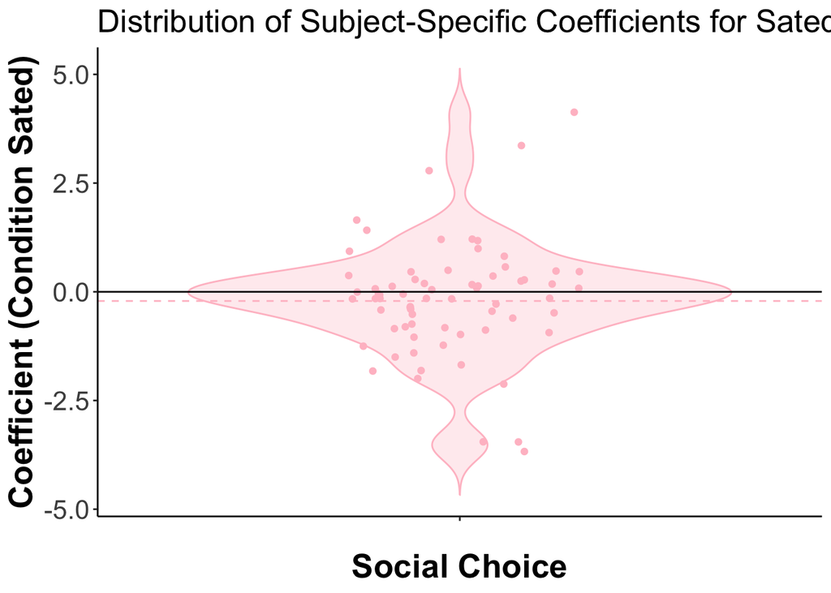

```r
# Extract the fixed effects
fixed_effects_social <- fixef(social_model3)

# Extract the random effects for each subject
random_effects_social <- ranef(social_model3)$subject

# Extract the fixed effect for `condition`
fixed_condition_social <- fixed_effects_social["conditionsated"]

# Extract the random slope for `condition`
random_condition_social <- ranef(social_model3)$subject[,"conditionsated"]

# Subject-specific coefficients for `condition`
subject_specific_condition_social <- fixed_condition_social + random_condition_social

subject_specific_ds <- data.frame(
  subject = rownames(random_effects_social),
  condition_effect = subject_specific_condition_social
)

social_plot<-ggplot(subject_specific_ds, aes(x = "", y = condition_effect)) +
  geom_violin(trim = FALSE, color="pink", fill="pink", alpha=0.3) +
  geom_jitter(width = 0.2, color="pink") +
  geom_hline(yintercept = fixed_condition, color = "pink", linetype = "dashed") +
  geom_hline(yintercept = 0, color = "black", linetype = "solid") +
  myTheme +
  labs(title = "Distribution of Subject-Specific Coefficients for Sated Relative to Hungry Condition Effect",
       x = "Social Choice",
       y = "Coefficient (Condition Sated)") +
  myTheme
social_plot
```

#### 2.2.5 Sign test

```r
combined_summary1 <- data_social_combined %>%
  group_by(subject) %>%
  summarise(mean_choice = mean(choice2),std_error_choice = sd(choice2) / sqrt(n()))

median_social<- median(combined_summary1$mean_choice)

combined_summary1$type<-0
for (i in 1: nrow(combined_summary1)){
  if (combined_summary1$mean_choice[i] <= median_social) {
    combined_summary1$type[i]<-"altruist"
  } else {
    combined_summary1$type[i]<-"egoist"
  }
}
selected_columns <- combined_summary1 %>%
  select(subject, mean_choice, std_error_choice)

data_social_combined <- data_social_combined %>%
  left_join(combined_summary1, by = "subject")

combined_summary2 <- data_social_combined %>%
  group_by(subject, condition) %>%
  summarise(mean_choice2 = mean(choice2),std_error_choice2 = sd(choice2) / sqrt(n()))
selected_columns <- combined_summary2 %>%
  select(subject, condition, mean_choice2, std_error_choice2)

data_social_combined <- data_social_combined %>%
  left_join(selected_columns, by = c("subject", "condition"))
```

Plot 1

```r
data_social_sum <- data_social_combined %>%
  group_by(subject, condition) %>%
  summarise(mean_choice_all = unique(mean_choice), std_error_choice_all = unique(std_error_choice),
            mean_choice = unique(mean_choice2), std_error_choice_all = unique(std_error_choice2),
            type=unique(type))
# Calculate mean_choice_all and std_error_choice_all for altruists and egoists
overall_means <- data_social_sum %>%
  group_by(type) %>%
  summarize(mean_choice = mean(mean_choice_all),
            std_error = mean(std_error_choice_all)) %>%
  mutate(condition = "Overall")

# Prepare the data for the other four bars
type_condition_means <- data_social_sum %>%
  group_by(type, condition) %>%
  summarize(mean_choice = mean(mean_choice),
            std_error = mean(std_error_choice_all))
```

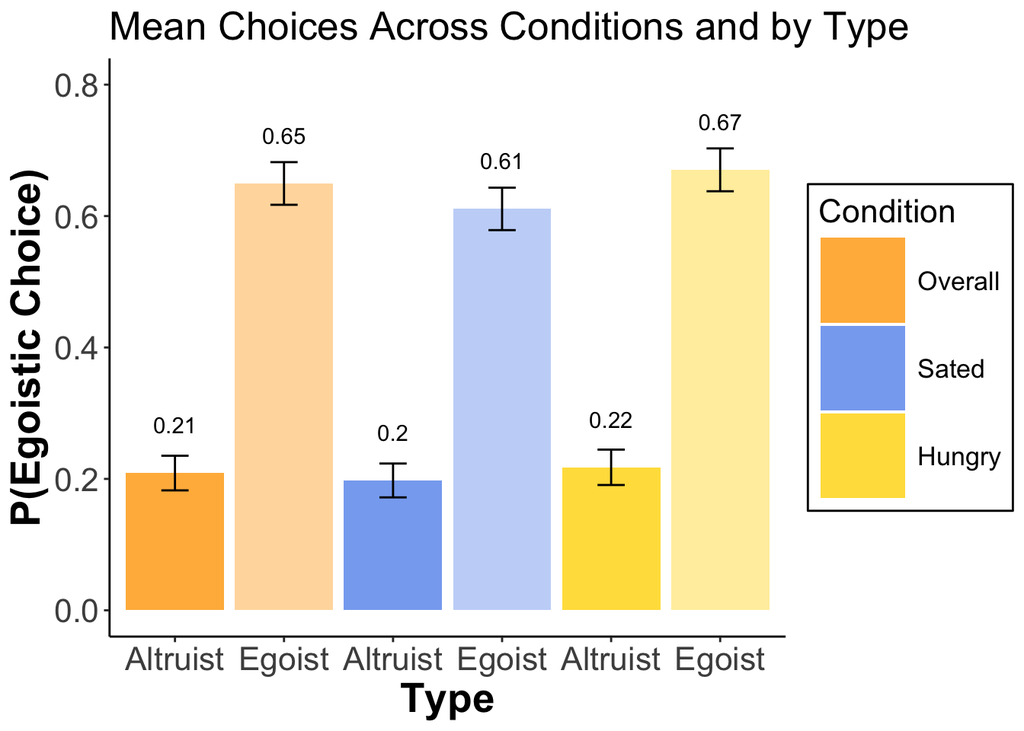

```r
# Combine the data
plot_data <- bind_rows(overall_means, type_condition_means)

# Create custom labels and colors
plot_data <- plot_data %>%
  mutate(
    custom_label = case_when(
      condition == "Overall" & type == "egoist" ~ "Egoistic Choice",
      condition == "Overall" & type == "altruist" ~ "Altruistic Choice",
      TRUE ~ paste(type, condition)
    ),
    custom_color = case_when(
      condition == "Overall" & type == "egoist" ~ "orange3",
      condition == "Overall" & type == "altruist" ~ "orange",
      condition == "sated" ~ "cornflowerblue",
      condition == "hungry" ~ "gold"
    )
  )

# Reorder factor levels for custom ordering
plot_data$custom_label <- factor(plot_data$custom_label,
                                 levels = c("Altruistic Choice", "Egoistic Choice",
                                            "altruist sated", "egoist sated",
                                            "altruist hungry", "egoist hungry"))

# Create a new column for legend
plot_data$legend_label <- case_when(
  plot_data$condition == "Overall" ~ "Overall",
  plot_data$condition == "sated" ~ "Sated",
  plot_data$condition == "hungry" ~ "Hungry"
)

plot_data$custom_color <- case_when(
  plot_data$condition == "Overall" & plot_data$type == "egoist" ~ scales::alpha("orange", 0.4),
  plot_data$condition == "Overall" & plot_data$type == "altruist" ~ scales::alpha("orange", 0.8),
  plot_data$condition == "sated" & plot_data$type == "egoist" ~ scales::alpha("cornflowerblue", 0.4),
  plot_data$condition == "sated" & plot_data$type == "altruist" ~ scales::alpha("cornflowerblue", 0.8),
  plot_data$condition == "hungry" & plot_data$type == "egoist" ~ scales::alpha("gold", 0.4),
  plot_data$condition == "hungry" & plot_data$type == "altruist" ~ scales::alpha("gold", 0.8)
)

# Ensure legend_label is a factor with levels in the desired order
plot_data$legend_label <- factor(plot_data$legend_label, levels = c("Overall", "Sated", "Hungry"))

# Ensure legend_label is a factor with levels in the desired order
plot_data$legend_label <- factor(plot_data$legend_label, levels = c("Overall", "Sated", "Hungry"))

# Create the plot
ggplot(plot_data, aes(x = custom_label, y = mean_choice, fill = custom_color)) +
  geom_bar(stat = "identity", position = position_dodge()) +
  geom_errorbar(aes(ymin = mean_choice - std_error,
                    ymax = mean_choice + std_error),
                width = 0.25, position = position_dodge(width = 0.9)) +
  geom_text(aes(label = round(mean_choice, 2)),
            vjust = -2.5, position = position_dodge(0.9)) +
  scale_fill_identity(guide = "legend",
                      labels = c("Overall", "Sated", "Hungry"),
                      breaks = c(scales::alpha("orange", 0.8),
                                 scales::alpha("cornflowerblue", 0.8),
                                 scales::alpha("gold", 0.8))) +
  labs(title = "Mean Choices Across Conditions and by Type",
       x = "Type",
       y = "P(Egoistic Choice)",
       fill = "Condition") +
  ylim(0, 0.8) +
  scale_x_discrete(labels = c("Altruistic Choice" = "Altruist",
                              "Egoistic Choice" = "Egoist",
                              "altruist sated" = "Altruist",
                              "egoist sated" = "Egoist",
                              "altruist hungry" = "Altruist",
                              "egoist hungry" = "Egoist")) +
  myTheme #+
```

```r
  #theme(axis.text.x = element_text(angle = 0, hjust = 0.5),
        #legend.position = "right")

ggsave("socialchoice_bytype.png", plot = last_plot(), dpi = 300)
### stats necessary?? Direction seems good, but no sign diff!
```

stats

```r
sum_social_h<-subset(data_social_sum, condition =='hungry')
sum_social_s<-subset(data_social_sum, condition =='sated')

sum_social_ego_h<-subset(sum_social_h, type =='egoist')
sum_social_ego_s<-subset(sum_social_s, type =='egoist')

sum_social_alt_h<-subset(sum_social_h, type =='altruist')
sum_social_alt_s<-subset(sum_social_s, type =='altruist')

ttest<-t.test(sum_social_ego_h$mean_choice, sum_social_ego_s$mean_choice, paired = TRUE)
ttest
```

```
##
##  Paired t-test
##
## data:  sum_social_ego_h$mean_choice and sum_social_ego_s$mean_choice
## t = 0.99556, df = 34, p-value = 0.3265
## alternative hypothesis: true mean difference is not equal to 0
## 95 percent confidence interval:
##  -0.06192191  0.18085371
## sample estimates:
## mean difference
##       0.0594659
```

```r
ttest2<-t.test(sum_social_alt_h$mean_choice, sum_social_alt_s$mean_choice, paired = TRUE)
ttest2
```

```
##
##  Paired t-test
##
## data:  sum_social_alt_h$mean_choice and sum_social_alt_s$mean_choice
## t = 0.74171, df = 34, p-value = 0.4634
## alternative hypothesis: true mean difference is not equal to 0
## 95 percent confidence interval:
##  -0.03480198  0.07480544
## sample estimates:
## mean difference
##      0.02000173
```

```r
effect_size3 <- ttest$statistic / sqrt(ttest$parameter)
```

Plot 2

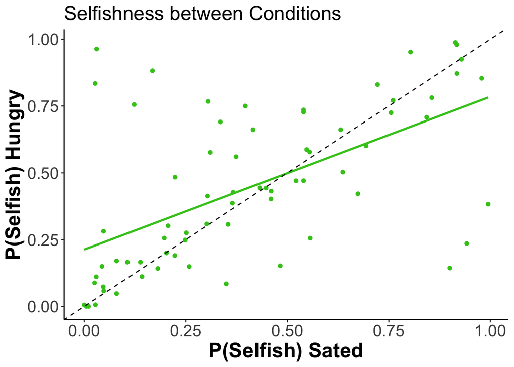

```r
signchange <- combined_summary2 %>%
  group_by(subject) %>%
  summarise(subtracted_choice = (mean_choice2[condition == "sated"]) - (mean_choice2[condition == "hungry"]),
            satedchoice=(mean_choice2[condition == "sated"]),
            hungrychoice=(mean_choice2[condition == "hungry"]))

correlation <- cor.test(signchange$satedchoice, signchange$hungrychoice)
scatter_plot <- ggplot(signchange, aes(x = satedchoice, y = hungrychoice)) +
  geom_point(color = "#3CC71E")+
  geom_smooth(method = "lm", se = FALSE, color = "#3CC71E") +
  geom_abline(intercept = 0, slope = 1, color = "black", linetype="dashed") +
  labs(title = "Selfishness between Conditions", x = "P(Selfish) Sated", y = "P(Selfish) Hungry")+
  myTheme
scatter_plot
```

```r
ggsave("Selfishness correlation.png", plot = last_plot(), dpi = 300)
correlation
```

```
##
##  Pearson's product-moment correlation
##
## data:  signchange$satedchoice and signchange$hungrychoice
## t = 5.8879, df = 68, p-value = 1.333e-07
## alternative hypothesis: true correlation is not equal to 0
## 95 percent confidence interval:
##  0.4008535 0.7180273
## sample estimates:
##       cor
## 0.5810941
```

#### 2.2.6 Hypothesis

… “hungry participants are more likely to choose in line with their idiosyncratic tendencies (i.e., egoistic individuals are more likely to choose egoistic options in a hungry compared to a satiated state and altruistic individuals are more likely to choose an altruistic option in a hungry compared to a satiated state)”

```r
#visual exploration
```

### 2.3 Discount

We predict a substantial spillover effect of hunger state on intertemporal discounting, that is, hungry sooner smaller rewards over delayed larger rewards more often compared to satiated participants. This will also be reflected in shorter response times towards sooner smaller reward options in the hungry condition. #### 2.3.1 Preparation Is Random effects justified?

```r
data_discount_combined <- data_discount_combined %>%
  mutate(choice = ifelse(
    (time_left > time_right & response == 'left') |
    (time_left < time_right & response == 'right'),
    "patient",
    "impulsive"
  ))

data_discount_combined <- data_discount_combined %>%
  mutate(choice2 = case_when(
    choice == "impulsive" ~ 1,
    choice == "patient" ~ 0,
    TRUE ~ NA_real_  # Handle other cases, if any
  ))

data_discount_combined <- data_discount_combined %>%
  mutate(response2 = case_when(
    response == "left" ~ 1,
    response == "right" ~ 0,
    TRUE ~ NA_real_  # Handle other cases, if any
  ))

#is random effects justified?
discount_model0 <- glm(choice2~1, data=data_discount_combined, family=binomial)
discount_model1 <- glmer(choice2~(1|subject), data=data_discount_combined, family=binomial, control = glmerControl(optimizer = "bobyqa"))
discount_model2 <- glmer(choice2~(1+condition|subject), data=data_discount_combined, family=binomial, , control = glmerControl(optimizer = "bobyqa"))

AIC(logLik(discount_model0))
```

```
## [1] 30001.91
```

```r
AIC(logLik(discount_model1))
```

```
## [1] 24904.56
```

```r
AIC(logLik(discount_model2))
```

```
## [1] 24023.27
```

```r
# AIC of random effects model smaller, hence better
```

add rel. dwell time difference impatient - patient option

```r
data_discount_combined$dwelldiff_value_rel <- 0
for (i in 1:nrow(data_discount_combined)){
  if((data_discount_combined$choice2[i]==1) && (data_discount_combined$response2[i]==1)) { # value & left
    data_discount_combined$dwelldiff_value_rel[i] = (data_discount_combined$valueleft_time[i]+data_discount_combined$timeleft_time[i])/(data_discount_combined$valueright_time[i]+data_discount_combined$timeright_time[i]+data_discount_combined$valueleft_time[i]+data_discount_combined$timeleft_time[i])
  }else if ((data_discount_combined$choice2[i]==1) && (data_discount_combined$response2[i]==0)) { # value & right
    data_discount_combined$dwelldiff_value_rel[i] = (data_discount_combined$valueright_time[i]+data_discount_combined$timeright_time[i])/(data_discount_combined$valueleft_time[i]+data_discount_combined$timeleft_time[i]+data_discount_combined$valueright_time[i]+data_discount_combined$timeright_time[i])
  }else if ((data_discount_combined$choice2[i]==0) && (data_discount_combined$response2[i]==1)) { # time & left
    data_discount_combined$dwelldiff_value_rel[i] = (data_discount_combined$valueright_time[i]+data_discount_combined$timeright_time[i])/(data_discount_combined$valueleft_time[i]+data_discount_combined$timeleft_time[i]+data_discount_combined$valueright_time[i]+data_discount_combined$timeright_time[i])
  }else if ((data_discount_combined$choice2[i]==0) && (data_discount_combined$response2[i]==0)) { # time & right
    data_discount_combined$dwelldiff_value_rel[i] = (data_discount_combined$valueleft_time[i]+data_discount_combined$timeleft_time[i])/(data_discount_combined$valueright_time[i]+data_discount_combined$timeright_time[i]+data_discount_combined$valueleft_time[i]+data_discount_combined$timeleft_time[i])
  }
}

data_discount_combined <- subset(data_discount_combined,dwelldiff_value_rel!='NaN')
```

#### 2.3.2 Choice Model

```r
discount_model3 <- glmer(choice2~condition + scale(dwelldiff_value_rel) + (1+condition|subject), data=data_discount_combined, family=binomial(link="logit"), control=glmerControl(optimizer="bobyqa",optCtrl=list(maxfun=2e5)))

discount_model4 <- glmer(choice2~condition + scale(dwelldiff_value_rel) + scale(rel_dwelldiff_value) + BMI_cent + age_cent + condition * age_cent + scale(rel_dwelldiff_value) * BMI_cent + scale(rel_dwelldiff_value) * age_cent  +    (1+condition|subject), data=data_discount_combined, family=binomial(link="logit"), control=glmerControl(optimizer="bobyqa",optCtrl=list(maxfun=2e5)))
discount_model5 <- glmer(choice2~condition + scale(dwelldiff_value_rel) + scale(rel_dwelldiff_value) + BMI_cent + age_cent + scale(PA_change) + scale(NA_change)+ scale(hs_change) + scale(external) + scale(emotional) + scale(restricted) + scale(dwelldiff_value_rel) * scale(restricted) + (1+condition|subject), data=data_discount_combined, family=binomial(link="logit"), control=glmerControl(optimizer="bobyqa",optCtrl=list(maxfun=2e5)))

summary(discount_model3)
```

```
## Generalized linear mixed model fit by maximum likelihood (Laplace
##   Approximation) [glmerMod]
##  Family: binomial  ( logit )
## Formula: choice2 ~ condition + scale(dwelldiff_value_rel) + (1 + condition |
##     subject)
##    Data: data_discount_combined
## Control: glmerControl(optimizer = "bobyqa", optCtrl = list(maxfun = 2e+05))
##
##      AIC      BIC   logLik deviance df.resid
##  19674.2  19722.9  -9831.1  19662.2    24606
##
## Scaled residuals:
##     Min      1Q  Median      3Q     Max
## -7.1791 -0.4857 -0.2056  0.2405 17.6112
##
## Random effects:
##  Groups  Name           Variance Std.Dev. Corr
##  subject (Intercept)    2.000    1.414
##          conditionsated 1.358    1.165    -0.40
## Number of obs: 24612, groups:  subject, 70
##
## Fixed effects:
##                            Estimate Std. Error z value Pr(>|z|)
## (Intercept)                -1.67674    0.17346  -9.666   <2e-16 ***
## conditionsated             -0.19000    0.14902  -1.275    0.202
## scale(dwelldiff_value_rel)  1.18385    0.02321  50.998   <2e-16 ***
## ---
## Signif. codes:  0 '***' 0.001 '**' 0.01 '*' 0.05 '.' 0.1 ' ' 1
##
## Correlation of Fixed Effects:
##             (Intr) cndtns
## conditinstd -0.419
## scl(dwll__) -0.066 -0.001
```

```r
summary(discount_model4)
```

```
## Generalized linear mixed model fit by maximum likelihood (Laplace
##   Approximation) [glmerMod]
##  Family: binomial  ( logit )
## Formula:
## choice2 ~ condition + scale(dwelldiff_value_rel) + scale(rel_dwelldiff_value) +
##     BMI_cent + age_cent + condition * age_cent + scale(rel_dwelldiff_value) *
##     BMI_cent + scale(rel_dwelldiff_value) * age_cent + (1 + condition |
##     subject)
##    Data: data_discount_combined
## Control: glmerControl(optimizer = "bobyqa", optCtrl = list(maxfun = 2e+05))
##
##      AIC      BIC   logLik deviance df.resid
##  19624.2  19721.6  -9800.1  19600.2    24600
##
## Scaled residuals:
##     Min      1Q  Median      3Q     Max
## -7.2054 -0.4861 -0.2025  0.2297 17.9255
##
## Random effects:
##  Groups  Name           Variance Std.Dev. Corr
##  subject (Intercept)    1.851    1.36
##          conditionsated 1.345    1.16     -0.42
## Number of obs: 24612, groups:  subject, 70
##
## Fixed effects:
##                                       Estimate Std. Error z value Pr(>|z|)
## (Intercept)                         -1.6755359  0.1673018 -10.015  < 2e-16 ***
## conditionsated                      -0.2032091  0.1485163  -1.368  0.17123
## scale(dwelldiff_value_rel)           1.1854082  0.0232968  50.883  < 2e-16 ***
## scale(rel_dwelldiff_value)           0.1370277  0.0284239   4.821 1.43e-06 ***
## BMI_cent                             0.0472028  0.0356306   1.325  0.18524
## age_cent                            -0.0546586  0.0219060  -2.495  0.01259 *
## conditionsated:age_cent             -0.0004053  0.0197826  -0.020  0.98366
## scale(rel_dwelldiff_value):BMI_cent -0.0370094  0.0067883  -5.452 4.98e-08 ***
## scale(rel_dwelldiff_value):age_cent  0.0122119  0.0041436   2.947  0.00321 **
## ---
## Signif. codes:  0 '***' 0.001 '**' 0.01 '*' 0.05 '.' 0.1 ' ' 1
##
## Correlation of Fixed Effects:
##             (Intr) cndtns scl(d__) scl(r__) BMI_cn ag_cnt cndt:_ s(__):B
## conditinstd -0.433
## scl(dwll__) -0.069 -0.002
## scl(rl_dw_) -0.005 -0.015  0.034
## BMI_cent    -0.018  0.016  0.004   -0.014
## age_cent     0.032 -0.032 -0.005   -0.012   -0.171
## cndtnstd:g_ -0.029  0.054  0.007    0.000    0.006 -0.443
## sc(__):BMI_ -0.005  0.008 -0.028    0.018   -0.109  0.005  0.008
## scl(rl__):_ -0.014  0.000  0.029    0.100    0.008 -0.057 -0.005 -0.223
```

```r
summary(discount_model5)
```

```
## Generalized linear mixed model fit by maximum likelihood (Laplace
##   Approximation) [glmerMod]
##  Family: binomial  ( logit )
## Formula:
## choice2 ~ condition + scale(dwelldiff_value_rel) + scale(rel_dwelldiff_value) +
##     BMI_cent + age_cent + scale(PA_change) + scale(NA_change) +
##     scale(hs_change) + scale(external) + scale(emotional) + scale(restricted) +
##     scale(dwelldiff_value_rel) * scale(restricted) + (1 + condition |
##     subject)
##    Data: data_discount_combined
## Control: glmerControl(optimizer = "bobyqa", optCtrl = list(maxfun = 2e+05))
##
##      AIC      BIC   logLik deviance df.resid
##  15045.7  15170.8  -7506.9  15013.7    18360
##
## Scaled residuals:
##     Min      1Q  Median      3Q     Max
## -6.1609 -0.4952 -0.2237  0.2375 15.2307
##
## Random effects:
##  Groups  Name           Variance Std.Dev. Corr
##  subject (Intercept)    1.3192   1.1485
##          conditionsated 0.9598   0.9797   -0.49
## Number of obs: 18376, groups:  subject, 53
##
## Fixed effects:
##                                              Estimate Std. Error z value
## (Intercept)                                  -1.60190    0.19372  -8.269
## conditionsated                               -0.32254    0.26484  -1.218
## scale(dwelldiff_value_rel)                    1.24599    0.02656  46.917
## scale(rel_dwelldiff_value)                    0.12249    0.03234   3.788
## BMI_cent                                     -0.00183    0.03348  -0.055
## age_cent                                     -0.03197    0.01986  -1.609
## scale(PA_change)                             -0.05266    0.09324  -0.565
## scale(NA_change)                             -0.14028    0.10702  -1.311
## scale(hs_change)                             -0.01569    0.15835  -0.099
## scale(external)                               0.18047    0.17531   1.029
## scale(emotional)                             -0.32412    0.18308  -1.770
## scale(restricted)                             0.21390    0.15969   1.339
## scale(dwelldiff_value_rel):scale(restricted) -0.04689    0.02690  -1.743
##                                              Pr(>|z|)
## (Intercept)                                   < 2e-16 ***
## conditionsated                               0.223285
## scale(dwelldiff_value_rel)                    < 2e-16 ***
## scale(rel_dwelldiff_value)                   0.000152 ***
## BMI_cent                                     0.956422
## age_cent                                     0.107540
## scale(PA_change)                             0.572207
## scale(NA_change)                             0.189939
## scale(hs_change)                             0.921060
## scale(external)                              0.303271
## scale(emotional)                             0.076666 .
## scale(restricted)                            0.180422
## scale(dwelldiff_value_rel):scale(restricted) 0.081393 .
## ---
## Signif. codes:  0 '***' 0.001 '**' 0.01 '*' 0.05 '.' 0.1 ' ' 1
```

```
##
## Correlation matrix not shown by default, as p = 13 > 12.
## Use print(x, correlation=TRUE)  or
##     vcov(x)        if you need it
```

```r
anova(discount_model3, discount_model4)
```

```
## Data: data_discount_combined
## Models:
## discount_model3: choice2 ~ condition + scale(dwelldiff_value_rel) + (1 + condition | subject)
## discount_model4: choice2 ~ condition + scale(dwelldiff_value_rel) + scale(rel_dwelldiff_value) + BMI_cent + age_cent + condition * age_cent + scale(rel_dwelldiff_value) * BMI_cent + scale(rel_dwelldiff_value) * age_cent + (1 + condition | subject)
##                 npar   AIC   BIC  logLik deviance Chisq Df Pr(>Chisq)
## discount_model3    6 19674 19723 -9831.1    19662
## discount_model4   12 19624 19722 -9800.1    19600    62  6  1.764e-11 ***
## ---
## Signif. codes:  0 '***' 0.001 '**' 0.01 '*' 0.05 '.' 0.1 ' ' 1
```

#### 2.3.3 Response Time Model

```r
discount_RTmodel0 <- glm(RT/1000~1, data=data_discount_combined,family=Gamma(link="identity"))
discount_RTmodel1 <- glmer(RT/1000~(1|subject), data=data_discount_combined,family=Gamma(link="identity"))
discount_RTmodel2 <- glmer(RT/1000~(1+condition|subject), data=data_discount_combined,family=Gamma(link="identity"))
aic_glm <- AIC(logLik(discount_RTmodel0))
aic_glmer <- AIC(logLik(discount_RTmodel1))
aic_glmer2 <- AIC(logLik(discount_RTmodel2))
aic_glm
```

```
## [1] 78807.79
```

```r
aic_glmer
```

```
## [1] 65062.98
```

```r
aic_glmer2
```

```
## [1] 60325.63
```

```r
discount_modelRT3 <- glmer(RT/1000~condition + choice2 * scale(dwelldiff_value_rel) + (1+condition|subject), data=data_discount_combined, family=Gamma(link="identity"), control=glmerControl(optimizer="bobyqa",optCtrl=list(maxfun=2e5)))
discount_modelRT4 <- glmer(RT/1000~condition + choice2 + scale(dwelldiff_value_rel) + scale(rel_dwelldiff_value) + BMI_cent + age_cent + choice2 * scale(dwelldiff_value_rel)  + condition * age_cent + scale(rel_dwelldiff_value) * BMI_cent + scale(rel_dwelldiff_value) * age_cent  +    (1+condition|subject), data=data_discount_combined, family=Gamma(link="identity"), control=glmerControl(optimizer="bobyqa",optCtrl=list(maxfun=2e5)))
summary(discount_modelRT3)
```

```
## Generalized linear mixed model fit by maximum likelihood (Laplace
##   Approximation) [glmerMod]
##  Family: Gamma  ( identity )
## Formula: RT/1000 ~ condition + choice2 * scale(dwelldiff_value_rel) +
##     (1 + condition | subject)
##    Data: data_discount_combined
## Control: glmerControl(optimizer = "bobyqa", optCtrl = list(maxfun = 2e+05))
##
##      AIC      BIC   logLik deviance df.resid
##  57435.9  57508.8 -28708.9  57417.9    24603
##
## Scaled residuals:
##     Min      1Q  Median      3Q     Max
## -1.5909 -0.6249 -0.2310  0.3530 14.0412
##
## Random effects:
##  Groups   Name           Variance Std.Dev. Corr
##  subject  (Intercept)    0.2810   0.5301
##           conditionsated 0.2706   0.5202   -0.19
##  Residual                0.2680   0.5177
## Number of obs: 24612, groups:  subject, 70
##
## Fixed effects:
##                                     Estimate Std. Error t value Pr(>|z|)
## (Intercept)                         2.096678   0.119217  17.587   <2e-16 ***
## conditionsated                     -0.013438   0.113959  -0.118    0.906
## choice2                             0.616887   0.022317  27.643   <2e-16 ***
## scale(dwelldiff_value_rel)          0.267466   0.006985  38.293   <2e-16 ***
## choice2:scale(dwelldiff_value_rel) -0.693330   0.017288 -40.105   <2e-16 ***
## ---
## Signif. codes:  0 '***' 0.001 '**' 0.01 '*' 0.05 '.' 0.1 ' ' 1
##
## Correlation of Fixed Effects:
##             (Intr) cndtns choic2 sc(__)
## conditinstd -0.154
## choice2     -0.023  0.003
## scl(dwll__)  0.027  0.002 -0.107
## chc2:sc(__) -0.006 -0.004 -0.653 -0.473
```

```r
summary(discount_modelRT4)
```

```
## Generalized linear mixed model fit by maximum likelihood (Laplace
##   Approximation) [glmerMod]
##  Family: Gamma  ( identity )
## Formula: RT/1000 ~ condition + choice2 + scale(dwelldiff_value_rel) +
##     scale(rel_dwelldiff_value) + BMI_cent + age_cent + choice2 *
##     scale(dwelldiff_value_rel) + condition * age_cent + scale(rel_dwelldiff_value) *
##     BMI_cent + scale(rel_dwelldiff_value) * age_cent + (1 + condition |
##     subject)
##    Data: data_discount_combined
## Control: glmerControl(optimizer = "bobyqa", optCtrl = list(maxfun = 2e+05))
##
##      AIC      BIC   logLik deviance df.resid
##  57362.6  57484.2 -28666.3  57332.6    24597
##
## Scaled residuals:
##     Min      1Q  Median      3Q     Max
## -1.5980 -0.6256 -0.2320  0.3530 14.8335
##
## Random effects:
##  Groups   Name           Variance Std.Dev. Corr
##  subject  (Intercept)    0.2719   0.5214
##           conditionsated 0.2634   0.5132   -0.19
##  Residual                0.2675   0.5172
## Number of obs: 24612, groups:  subject, 70
##
## Fixed effects:
##                                       Estimate Std. Error t value Pr(>|z|)
## (Intercept)                          2.0936996  0.1173073  17.848  < 2e-16 ***
## conditionsated                      -0.0129021  0.1123786  -0.115 0.908596
## choice2                              0.6091554  0.0222845  27.335  < 2e-16 ***
## scale(dwelldiff_value_rel)           0.2614702  0.0069813  37.453  < 2e-16 ***
## scale(rel_dwelldiff_value)           0.0447029  0.0064420   6.939 3.94e-12 ***
## BMI_cent                             0.0370852  0.0273051   1.358 0.174407
## age_cent                            -0.0163684  0.0150103  -1.090 0.275501
## choice2:scale(dwelldiff_value_rel)  -0.6821142  0.0173102 -39.405  < 2e-16 ***
## conditionsated:age_cent              0.0191370  0.0141037   1.357 0.174818
## scale(rel_dwelldiff_value):BMI_cent -0.0053553  0.0016020  -3.343 0.000829 ***
## scale(rel_dwelldiff_value):age_cent  0.0044265  0.0009805   4.514 6.35e-06 ***
## ---
## Signif. codes:  0 '***' 0.001 '**' 0.01 '*' 0.05 '.' 0.1 ' ' 1
```

[output cut: 12 more lines]

```
## scl(rl__):_ -0.003  0.001 -0.006 -0.016    0.130   -0.005 -0.021 -0.003  0.005
##             s(__):B
## conditinstd
## choice2
## scl(dwll__)
## scl(rl_dw_)
## BMI_cent
## age_cent
## chc2:sc(__)
## cndtnstd:g_
## sc(__):BMI_
## scl(rl__):_ -0.069
## optimizer (bobyqa) convergence code: 0 (OK)
## Model is nearly unidentifiable: very large eigenvalue
##  - Rescale variables?
```

```r
anova(discount_modelRT3, discount_modelRT4)
```

```
## Data: data_discount_combined
## Models:
## discount_modelRT3: RT/1000 ~ condition + choice2 * scale(dwelldiff_value_rel) + (1 + condition | subject)
## discount_modelRT4: RT/1000 ~ condition + choice2 + scale(dwelldiff_value_rel) + scale(rel_dwelldiff_value) + BMI_cent + age_cent + choice2 * scale(dwelldiff_value_rel) + condition * age_cent + scale(rel_dwelldiff_value) * BMI_cent + scale(rel_dwelldiff_value) * age_cent + (1 + condition | subject…
##                   npar   AIC   BIC logLik deviance  Chisq Df Pr(>Chisq)
## discount_modelRT3    9 57436 57509 -28709    57418
## discount_modelRT4   15 57363 57484 -28666    57333 85.299  6  2.862e-16 ***
## ---
## Signif. codes:  0 '***' 0.001 '**' 0.01 '*' 0.05 '.' 0.1 ' ' 1
```

##### Quantify effect of hunger

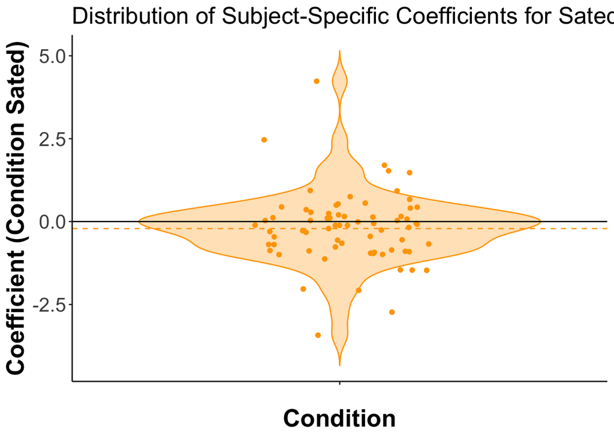

```r
# Extract the fixed effects
fixed_effects_discount <- fixef(discount_model3)

# Extract the random effects for each subject
random_effects_discount <- ranef(discount_model3)$subject

# Extract the fixed effect for `condition`
fixed_condition_discount <- fixed_effects_discount["conditionsated"]

# Extract the random slope for `condition`
random_condition_discount <- ranef(discount_model3)$subject[,"conditionsated"]

# Subject-specific coefficients for `condition`
subject_specific_condition_discount <- fixed_condition_discount + random_condition_discount

subject_specific_dd <- data.frame(
  subject = rownames(random_effects_discount),
  condition_effect = subject_specific_condition_discount
)

discount_plot<-ggplot(subject_specific_dd, aes(x = "", y = condition_effect)) +
  geom_violin(trim = FALSE, color="orange", fill="orange", alpha=0.3) +
  geom_jitter(width = 0.2, color="orange") +
  geom_hline(yintercept = fixed_condition, color = "orange", linetype = "dashed") +
  geom_hline(yintercept = 0, color = "black", linetype = "solid") +
  myTheme +
  labs(title = "Distribution of Subject-Specific Coefficients for Sated Relative to Hungry Condition Effect",
       x = "Condition",
       y ="Coefficient (Condition Sated)") +
  myTheme
discount_plot
```

## 5 “Spill over” Effect

1. Common graph

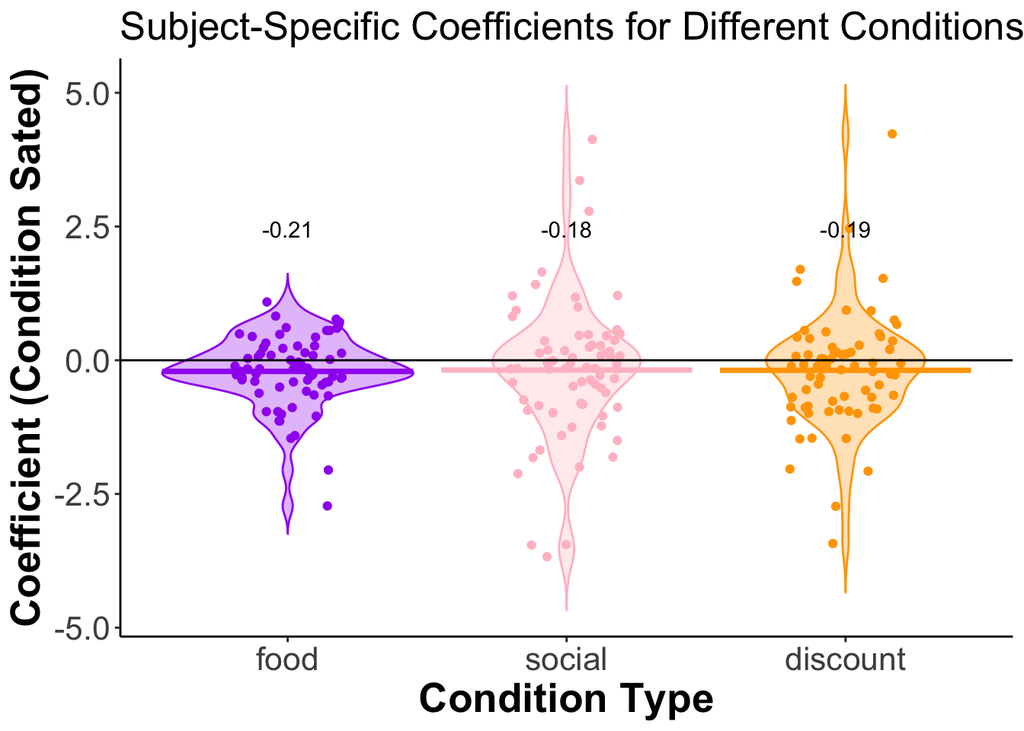

```r
# Combining data frames
subject_specific_df$conditiontype <- "food"
subject_specific_ds$conditiontype <- "social"
subject_specific_dd$conditiontype <- "discount"

# Ensure the color and jitter values are named for merging
subject_specific_df <- subject_specific_df %>%
  mutate(colour = "purple", fill = "purple", fixed_effect = fixed_condition)
subject_specific_ds <- subject_specific_ds %>%
  mutate(colour = "pink", fill = "pink", fixed_effect = fixed_condition_social)
subject_specific_dd <- subject_specific_dd %>%
  mutate(colour = "orange", fill = "orange", fixed_effect = fixed_condition_discount)

# Combine all three data frames into one
combined_df <- bind_rows(subject_specific_ds, subject_specific_df, subject_specific_dd)

# Set the order of the condition types
combined_df$conditiontype <- factor(combined_df$conditiontype, levels = c("food", "social", "discount"))

mean_values <- combined_df %>%
  group_by(conditiontype) %>%
  summarize(mean_coefficient = mean(condition_effect),na.rm = TRUE)

# Create the combined violin plot with mean lines for each condition type
combined_plot <- ggplot(combined_df, aes(x = conditiontype, y = condition_effect)) +
  geom_violin(aes(color = colour, fill = fill), trim = FALSE, alpha = 0.3) +
  geom_jitter(aes(color = colour), width = 0.2, height=0) +
  geom_hline(yintercept = 0, color = "black", linetype = "solid") +
  scale_color_identity() +
  scale_fill_identity() +
  myTheme +
  labs(title = "Subject-Specific Coefficients for Different Conditions",
       x = "Condition Type",
       y = "Coefficient (Condition Sated)") +
  myTheme +
  stat_summary(fun = mean, geom = "crossbar", color = c("purple","pink", "orange"), show.legend = FALSE)+
  geom_text(data = mean_values, aes(x = as.numeric(conditiontype), y = 2, label = round(mean_coefficient, digits = 2)), vjust = -1)
  #geom_path(aes(group = subject, color = "grey", alpha=0.2), alpha = 0.5, size=0.5)

# Print the plot
print(combined_plot)
```

```r
ggsave("spillover.png", combined_plot)
```

We do not observe this so called “spill-over effect”. While the mean coefficients across tasks are similar, the social and discounting task do not reach significance, due to its spread. It seems therefore that the effect of hungerstate across choice domains strongly depends on the individual and possible other latent variables are at play.

2. Correlate the effects on a subject level, idea People who are stronger affected in food domain may also be more affected in a different domain?

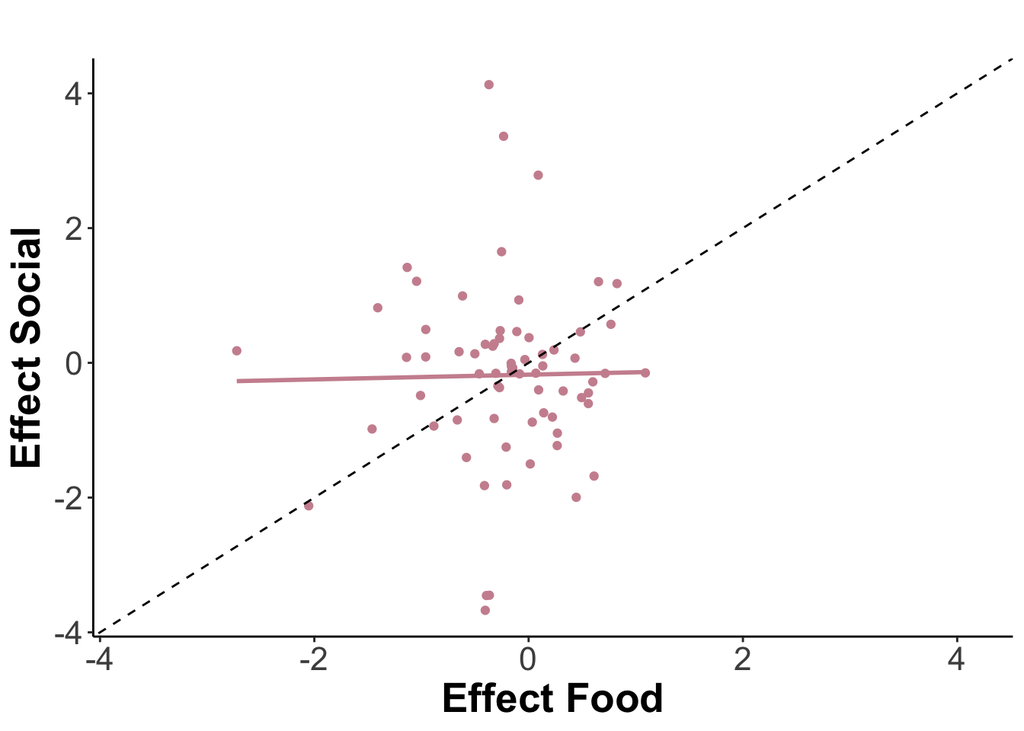

```r
# Transform the data frame into a wide format
library(tidyr)
wide_df <- combined_df %>%
  select(subject, conditiontype, condition_effect) %>%
  pivot_wider(names_from = conditiontype, values_from = condition_effect, names_prefix = "effect_")

wide_df <- na.omit(wide_df)

scatter_plot <- ggplot(wide_df, aes(x = effect_food, y = effect_social)) +
  geom_point(color = "pink3")+
  geom_smooth(method = "lm", se = FALSE, color = "pink3") +
  geom_abline(intercept = 0, slope = 1, color = "black", linetype="dashed") +
  labs(title = "", x = "Effect Food", y = "Effect Social")+
  xlim(min(wide_df$effect_social), max(wide_df$effect_social))+
  ylim(min(wide_df$effect_social), max(wide_df$effect_social))+
  myTheme
scatter_plot
```

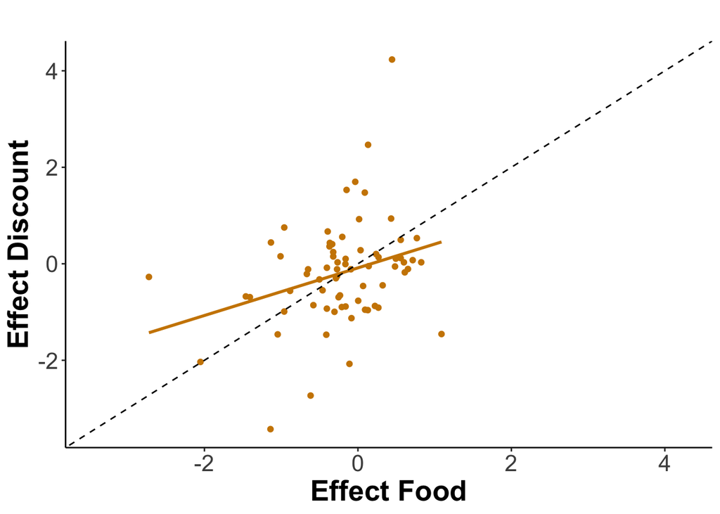

```r
scatter_plot2 <- ggplot(wide_df, aes(x = effect_food, y = effect_discount)) +
  geom_point(color = "orange3")+
  geom_smooth(method = "lm", se = FALSE, color = "orange3") +
  geom_abline(intercept = 0, slope = 1, color = "black", linetype="dashed") +
  labs(title = "", x = "Effect Food", y = "Effect Discount")+
  xlim(min(wide_df$effect_discount), max(wide_df$effect_discount))+
  ylim(min(wide_df$effect_discount), max(wide_df$effect_discount))+
  myTheme

scatter_plot2
```

```r
correlation <- cor.test(wide_df$effect_food, wide_df$effect_social)
correlation2 <- cor.test(wide_df$effect_food, wide_df$effect_discount)
correlation
```

```
##
##  Pearson's product-moment correlation
##
## data:  wide_df$effect_food and wide_df$effect_social
## t = 0.14647, df = 68, p-value = 0.884
## alternative hypothesis: true correlation is not equal to 0
## 95 percent confidence interval:
##  -0.2181248  0.2516832
## sample estimates:
##        cor
## 0.01775948
```

```r
correlation2
```

```
##
##  Pearson's product-moment correlation
##
## data:  wide_df$effect_food and wide_df$effect_discount
## t = 2.5935, df = 68, p-value = 0.01162
## alternative hypothesis: true correlation is not equal to 0
## 95 percent confidence interval:
##  0.06997865 0.49976183
## sample estimates:
##       cor
## 0.3000194
```

```r
ggsave("food_social_corr.png", scatter_plot)
ggsave("food_discount_corr.png.png", scatter_plot2)
# also check correlation social discount!
```

People who change their food choices more strongly under hunger, also seem to change their discounting decisions, while there is no relation to social choices.